# Bycatch Estimation and Expansion in STAN

Eric J. Ward

2019-06-04

## Load library

```r
require(devtools)
#devtools::install_github("eric-ward/bycatch")
library(bycatch)
set.seed(123)
```

### Load data

```r
# replace this with your own data frame
d = data.frame("Year"= 2002:2014,
  "Takes" = c(0, 0, 0, 0, 0, 0, 0, 0, 1, 3, 0, 0, 0),
  "expansionRate" = c(24, 22, 14, 32, 28, 25, 30,  7, 26, 21, 22, 23, 27),
  "Sets" = c(391, 340, 330, 660, 470, 500, 330, 287, 756, 673, 532, 351, 486))
```

## Simple model with constant bycatch, no covariates

We’ll start by fitting a model with constant bycatch rate,

```r
fit = fit_bycatch(Takes ~ 1, data=d, time="Year", effort="Sets", family="poisson",
  time_varying = FALSE)
```

If divergent transition warnings or other issues indicating lack of convergence are a problem, we can try changing some of the control arguments, e.g.

```r
fit = fit_bycatch(Takes ~ 1, data=d, time="Year", effort="Sets", family="poisson",
  time_varying = FALSE, control=list(adapt_delta=0.99,max_treedepth=20))
```

We can also increase the iterations and number of chains from the defaults (1000 and 3),

```r
fit = fit_bycatch(Takes ~ 1, data=d, time="Year", effort="Sets", family="poisson",
  time_varying = FALSE, iter=3000, chains=4)
```

### Make plots

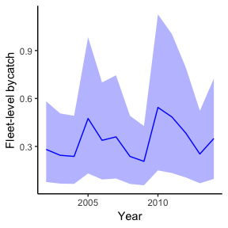

Estimated fleet-level bycatch (not expanded by observer coverage), incorporating data on takes, effort.

```r
plot_fitted(fit, xlab="Year", ylab = "Fleet-level bycatch")
```

We can include points also,

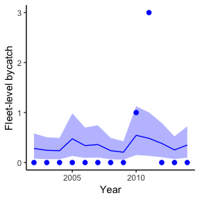

Estimated fleet-level bycatch (not expanded by observer coverage), incorporating data on takes, effort. Dots represent observed bycatch events.

```r
plot_fitted(fit, xlab="Year", ylab = "Fleet-level bycatch", include_points = TRUE)
```

### Extracting model selection information (LOOIC)

The `loo` package in R provides a nice interface for extracting leave one out information criterion (LOOIC) from `stanfit` objects. Like AIC, lower is better. Values of LOOIC can be used to compare models with the same response but different structure (covariates or not, time-varying bycatch or not, etc).

```r
loo::loo(fit$fitted_model)$estimates
```

```
##            Estimate        SE
## elpd_loo -11.177868  6.043199
## p_loo      2.526928  2.162952
## looic     22.355736 12.086398
```

## Expanding bycatch estimates

Using our example above, the observer coverage for that dataset was less than 100% and so our estimates need to be expanded to the fleetwide level. There are some important `control` arguments here that are left at defaults, but should maybe be changed for huge numbers of bycatch.

```r
expanded = expand(fit, coverage = d$expansionRate)
```

And we can then plot these estimates. Like the previous function we can specify whether to include the raw points or not.

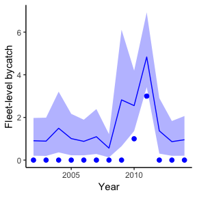

Estimated fleet-level expanded bycatch, incorporating data on takes, effort, and observer coverage. Dots represent observed bycatch events.

```r
plot_expanded(fitted_model=fit, expanded_estimates = expanded, xlab="Year", ylab = "Fleet-level bycatch", include_points = TRUE)
```

### Make table of expanded bycatch estimates

We can also do things like summarize the expanded estimates in table form

```r
df = data.frame("time" = d[,"Year"],
  "mean" = apply(expanded_estimates, 2, mean),
  "median" = apply(expanded_estimates, 2, quantile, 0.5),
  "lower95" = apply(expanded_estimates, 2, quantile, 0.025),
  "upper95" = apply(expanded_estimates, 2, quantile, 0.975))

write.table(df, "estimated_bycatch.csv", row.names=F, col.names=T, sep=",")
```

## Negative binomial example

Using our example dataset above, we can also switch from the Poisson model to Negative Binomial.

```r
fit = fit_bycatch(Takes ~ 1, data=d, time="Year", effort="Sets", family="nbinom2",
  time_varying = FALSE)
```

The degree of overdispersion here is stored in the variable `nb2_phi`, which we can get with

```r
phi = rstan::extract(fit$fitted_model)$nb2_phi
```

## Example with covariates

Following [Martin et al. 2015](http://onlinelibrary.wiley.com/doi/10.1890/14-0059.1/abstract) we can include fixed or continuous covariates.

For example, we could include a julian day, and a break point (representing a regulatory change for example) in the data. We could model the first variable as a continuous predictor and the second as a factor.

```r
d$Day = sample(seq(220,280),size=nrow(d),replace=T)
d$Reg = ifelse(d$Year < 2008, 0, 1)
```

Using the formula interface makes it easy to include covariates,

```r
fit = fit_bycatch(Takes ~ Day + Reg, data=d, time="Year", effort="Sets", family="poisson",
  time_varying = FALSE)
```

We can get the 3 covariate effects out with the following call:

```r
betas = rstan::extract(fit$fitted_model)$beta
```

Note that ‘betas’ has 3 columns. These correspond to (1) the intercept, (2) continuous predictor, and (3) factor variable above. If we didn’t include the covariates, we’d still estimate beta[1] as the intercept.

## Fit model with time-varying effects

To incorporate potential autocorrelation, we can fit a model with time-varying random effects. This is equivalent to a dynamic linear model with time varying intercept in a Poisson GLM.

```r
fit = fit_bycatch(Takes ~ 1, data=d, time="Year", effort="Sets", family="poisson",
  time_varying = TRUE)
```

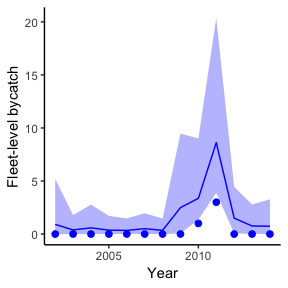

Estimated fleet-level expanded bycatch from the model with time-varying effects, incorporating data on takes, effort, and observer coverage. Dots represent observed bycatch events.

```r
expanded = expand(fit, coverage=d$expansionRate)
plot_expanded(fitted_model=fit, expanded_estimates = expanded, xlab="Year", ylab = "Fleet-level bycatch", include_points = TRUE)
```

## Fit model with no bycatch events

```r
# replace this with your own data frame
d = data.frame("Year"= 2002:2014,
  "Takes" = c(0, 0, 0, 0, 0, 0, 0, 0, 0, 0, 0, 0, 0),
  "expansionRate" = c(24, 22, 14, 32, 28, 25, 30,  7, 26, 21, 22, 23, 27),
  "Sets" = c(391, 340, 330, 660, 470, 500, 330, 287, 756, 673, 532, 351, 486))
```

```r
fit = fit_bycatch(Takes ~ 1, data=d, time="Year", effort="Sets", family="poisson",
  time_varying = FALSE)
```

[figure not shown]

Estimated fleet-level expanded bycatch from the dataset with no events, incorporating effort, and observer coverage. Dots represent observed bycatch events.

```r
expanded = expand(fit, coverage=d$expansionRate)
plot_expanded(fitted_model=fit, expanded_estimates = expanded, xlab="Year", ylab = "Fleet-level bycatch", include_points = TRUE)
```